# 02 — Aging clock: train on GTEx, apply to TCGA

Pan-can aging pipeline

March 05, 2026

```r
suppressPackageStartupMessages({
  library(here)
  library(glmnet)
  library(dplyr)
  library(tibble)
  library(ggplot2)
  library(stringr)
  library(reactable)
})

# Rmd-friendly verbose printing
vcat <- function(...) if (isTRUE(params$verbose)) cat(..., "\n")
```

```r
reactable_pretty <- function(df, digits = 3) {
  df2 <- df %>% mutate(across(where(is.numeric), ~ signif(., digits)))
  reactable::reactable(
    df2,
    searchable = TRUE,
    resizable = TRUE,
    striped = TRUE,
    highlight = TRUE,
    defaultPageSize = 10
  )
}
```

## Load processed objects

```r
analysis_id <- paste0(params$tcga_project, "__", params$gtex_project)
proc_dir <- file.path(here::here(params$out_root), analysis_id)
suffix   <- paste0("-", params$feature_set)

vcat("proc_dir = ", proc_dir)
```

```
## proc_dir =  /restricted/projectnb/agedisease/projects/pancancer_aging_pbock/manuscript_analyses/results/derived/GTEx/BRCA__BREAST
```

```r
scores_gtex <- readRDS(file.path(proc_dir, paste0("ssgsea_scores_gtex", suffix, ".rds")))
scores_nt   <- readRDS(file.path(proc_dir, paste0("ssgsea_scores_nt",   suffix, ".rds")))
scores_pt   <- readRDS(file.path(proc_dir, paste0("ssgsea_scores_pt",   suffix, ".rds")))

metadata <- readRDS(file.path(proc_dir, "sample_metadata.rds"))

# sanity: sample IDs match
stopifnot(all(colnames(scores_gtex) %in% rownames(metadata)))
stopifnot(all(colnames(scores_pt)   %in% rownames(metadata)))
stopifnot(all(colnames(scores_nt)   %in% rownames(metadata)))
```

## Prepare matrices

```r
# Training set (GTEx)
meta_gtex <- metadata[colnames(scores_gtex), , drop = FALSE]
x_gtex    <- t(scores_gtex)                 # samples × pathways
y_gtex    <- meta_gtex$age_years

# Drop missing ages (required for training)
keep_train <- is.finite(y_gtex)
x_gtex <- x_gtex[keep_train, , drop = FALSE]
y_gtex <- y_gtex[keep_train]

stopifnot(nrow(x_gtex) == length(y_gtex))

# IMPORTANT: name the response for safe alignment downstream
names(y_gtex) <- rownames(x_gtex)

# Test sets (TCGA)
meta_nt <- metadata[colnames(scores_nt), , drop = FALSE]
x_nt    <- t(scores_nt)
age_nt  <- meta_nt$age_years
age_nt  <- setNames(age_nt, rownames(x_nt))

meta_pt <- metadata[colnames(scores_pt), , drop = FALSE]
x_pt    <- t(scores_pt)
age_pt  <- meta_pt$age_years
age_pt  <- setNames(age_pt, rownames(x_pt))

has_nat <- nrow(x_nt) >= params$min_nat
vcat("GTEx n=", nrow(x_gtex), " | PT n=", nrow(x_pt), " | NAT n=", nrow(x_nt), " | has_nat=", has_nat)
```

```
## GTEx n= 482  | PT n= 1127  | NAT n= 112  | has_nat= TRUE
```

## Train an elastic-net clock on GTEx (tune alpha & lambda)

This intentionally does **not** do GTEx-anchored bias-correction or any decoupling analyses. It only trains the clock and produces:

- raw predicted ages (GTEx / NAT / PT)
- raw Δ-age = (predicted − chronological)
- **tumor-intra RAA** = residuals from `lm(predicted ~ chronological)` within tumors

### Key implementation detail (no CV leakage)

To avoid CV leakage from preprocessing, we **do not** scale `x_gtex` globally before CV. Instead, we set `standardize = TRUE` inside `cv.glmnet()`, which standardizes **within each CV fold** (using only the training portion of each fold), matching what caret’s `preProcess=c("center","scale")` does.

```r
set.seed(params$seed)

# --- age-stratified folds (deciles) ---
k <- params$n_folds
age_bin <- dplyr::ntile(y_gtex, 10)

foldid <- integer(length(y_gtex))
for (b in sort(unique(age_bin))) {
  idx <- which(age_bin == b)
  foldid[idx] <- sample(rep(seq_len(k), length.out = length(idx)))
}
stopifnot(all(foldid %in% seq_len(k)))

# --- alpha/lambda grid ---
alpha_grid <- as.numeric(params$alpha_grid)
alpha_grid <- alpha_grid[is.finite(alpha_grid)]
if (length(alpha_grid) == 0) alpha_grid <- seq(0, 1, by = 0.1)
alpha_grid <- sort(unique(alpha_grid))

lambda_grid <- 10 ^ seq(params$lambda_min_exp, params$lambda_max_exp, length.out = params$n_lambda)

get_idx <- function(cvfit, lam) which.min(abs(cvfit$lambda - lam))

tune_list <- vector("list", length(alpha_grid))
names(tune_list) <- as.character(alpha_grid)

for (i in seq_along(alpha_grid)) {
  a <- alpha_grid[i]

  cvfit_a <- cv.glmnet(
    x = x_gtex,
    y = y_gtex,
    alpha = a,
    family = "gaussian",
    foldid = foldid,
    type.measure = "mae",
    lambda = lambda_grid,
    standardize = TRUE,
    intercept = TRUE
  )

  idx_min <- get_idx(cvfit_a, cvfit_a$lambda.min)
  idx_1se <- get_idx(cvfit_a, cvfit_a$lambda.1se)

  tune_list[[i]] <- list(
    alpha = a,
    cvfit = cvfit_a,
    lambda_min = cvfit_a$lambda[idx_min],
    mae_min    = cvfit_a$cvm[idx_min],
    nzero_min  = cvfit_a$nzero[idx_min],
    lambda_1se = cvfit_a$lambda[idx_1se],
    mae_1se    = cvfit_a$cvm[idx_1se],
    nzero_1se  = cvfit_a$nzero[idx_1se]
  )
}

tune_tbl <- bind_rows(lapply(tune_list, function(z) {
  tibble(
    alpha = z$alpha,
    lambda.min = z$lambda_min,
    MAE.min    = z$mae_min,
    nzero.min  = z$nzero_min,
    lambda.1se = z$lambda_1se,
    MAE.1se    = z$mae_1se,
    nzero.1se  = z$nzero_1se
  )
})) %>% dplyr::arrange(alpha)

reactable_pretty(tune_tbl)
```

| alpha | lambda.min | MAE.min | nzero.min | lambda.1se | MAE.1se | nzero.1se |
| --- | --- | --- | --- | --- | --- | --- |
| 0 | 0.925 | 9.61 | 50 | 19.4 | 9.87 | 50 |
| 0.1 | 0.579 | 9.58 | 35 | 3.77 | 9.84 | 25 |
| 0.2 | 0.458 | 9.56 | 33 | 1.87 | 9.79 | 19 |
| 0.3 | 0.363 | 9.55 | 31 | 1.17 | 9.76 | 20 |
| 0.4 | 0.287 | 9.55 | 26 | 0.925 | 9.76 | 19 |
| 0.5 | 0.227 | 9.55 | 26 | 0.732 | 9.75 | 18 |
| 0.6 | 0.18 | 9.55 | 28 | 0.579 | 9.74 | 18 |
| 0.7 | 0.18 | 9.54 | 25 | 0.579 | 9.77 | 17 |
| 0.8 | 0.142 | 9.54 | 28 | 0.458 | 9.75 | 18 |
| 0.9 | 0.142 | 9.54 | 25 | 0.458 | 9.78 | 17 |

[output cut: 1 more lines]

```r
metric_col  <- if (params$lambda_choice == "lambda.min") "MAE.min" else "MAE.1se"
lambda_col  <- if (params$lambda_choice == "lambda.min") "lambda.min" else "lambda.1se"
nzero_col   <- if (params$lambda_choice == "lambda.min") "nzero.min" else "nzero.1se"

best_row <- tune_tbl %>% dplyr::slice(which.min(.data[[metric_col]]))

best_alpha  <- best_row$alpha
best_lambda <- best_row[[lambda_col]]
best_mae    <- best_row[[metric_col]]
best_nzero  <- best_row[[nzero_col]]

idx_best <- which.min(tune_tbl[[metric_col]])
best_cvfit <- tune_list[[idx_best]]$cvfit

vcat("Best elastic-net: alpha=", best_alpha,
    " | ", params$lambda_choice, "=", signif(best_lambda, 4),
    " | CV MAE=", signif(best_mae, 4),
    " | nzero=", best_nzero)
```

```
## Best elastic-net: alpha= 0.6  |  lambda.1se = 0.579  | CV MAE= 9.736  | nzero= 18
```

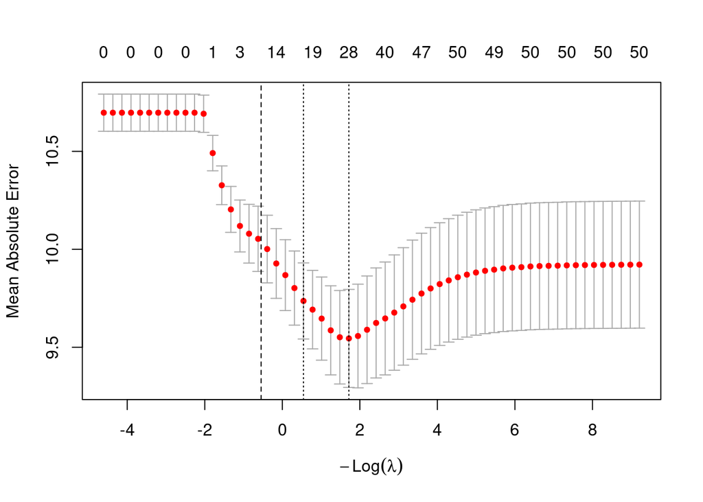

```r
plot(best_cvfit)
abline(v = log(best_lambda), lty = 2)
```

## Fit final model and predict

```r
enet_model <- glmnet(
  x = x_gtex,
  y = y_gtex,
  alpha = best_alpha,
  family = "gaussian",
  lambda = best_lambda,
  standardize = TRUE,
  intercept = TRUE
)

pred_gtex <- as.numeric(predict(enet_model, newx = x_gtex, s = best_lambda))
pred_pt   <- if (nrow(x_pt) > 0) as.numeric(predict(enet_model, newx = x_pt, s = best_lambda)) else numeric()
pred_nt   <- if (nrow(x_nt) > 0) as.numeric(predict(enet_model, newx = x_nt, s = best_lambda)) else numeric()

names(pred_gtex) <- rownames(x_gtex)
if (length(pred_pt)) names(pred_pt) <- rownames(x_pt)
if (length(pred_nt)) names(pred_nt) <- rownames(x_nt)

# Extract the training scalers used by glmnet (for reproducibility / downstream storage)
# NOTE: these are the GTEx training mean/sd used internally by glmnet when standardize=TRUE
x_center <- if (!is.null(enet_model$xm)) enet_model$xm else colMeans(x_gtex, na.rm = TRUE)
x_scale  <- if (!is.null(enet_model$xs)) enet_model$xs else apply(x_gtex, 2, sd, na.rm = TRUE)
x_scale[!is.finite(x_scale) | x_scale == 0] <- 1

if (is.null(names(x_center))) names(x_center) <- colnames(x_gtex)
if (is.null(names(x_scale)))  names(x_scale)  <- colnames(x_gtex)

stopifnot(identical(names(x_center), colnames(x_gtex)))
stopifnot(identical(names(x_scale),  colnames(x_gtex)))
```

## Retained pathways (non-zero coefficients)

```r
coef_mat <- as.matrix(coef(enet_model))
a_orig   <- as.numeric(coef_mat[1, 1])
b_orig   <- setNames(as.numeric(coef_mat[-1, 1]), rownames(coef_mat)[-1])

retained_tbl <- tibble(
  pathway = names(b_orig),
  coefficient = as.numeric(b_orig)
) %>%
  filter(is.finite(coefficient), coefficient != 0) %>%
  mutate(direction = ifelse(coefficient > 0, "Older", "Younger")) %>%
  arrange(desc(abs(coefficient)))

vcat("Retained pathways (non-zero): n = ", nrow(retained_tbl))
```

```
## Retained pathways (non-zero): n =  18
```

```r
reactable_pretty(retained_tbl)
```

| pathway | coefficient | direction |
| --- | --- | --- |
| P53 Pathway | 0.0107 | Older |
| Glycolysis | -0.0106 | Younger |
| Uv Response Up | -0.00592 | Younger |
| Unfolded Protein Response | 0.00458 | Older |
| Wnt Beta Catenin Signaling | -0.00436 | Younger |
| Il2 Stat5 Signaling | 0.00418 | Older |
| G2m Checkpoint | -0.00399 | Younger |
| Myogenesis | 0.00359 | Older |
| Pancreas Beta Cells | -0.00347 | Younger |
| Complement | 0.002 | Older |

[output cut: 8 more lines]

## Create a ClockSHAP-ready clock parameterization (upstream contract)

ClockSHAP’s `linear_clock(alpha, beta, mu, sigma)` uses the standardized form:

$$\hat y = \alpha + \sum_j \beta_j \cdot \frac{x_j - \mu_j}{\sigma_j}$$

However, `coef(glmnet)` corresponds to coefficients on the **original x scale**:

$$\hat y = a + \sum_j b_j x_j$$

To keep downstream scripts simple and unambiguous, we convert and save **both**: - `clock_raw`: `(a, b)` on the original x scale - `clock_cs`: `(alpha_cs, beta_cs, mu, sigma)` in ClockSHAP standardized form

Conversion: - `beta_cs_j = b_j * sigma_j` - `alpha_cs = a + sum_j b_j * mu_j`

```r
# Align to the training feature set order
feat <- colnames(x_gtex)
b_orig <- b_orig[feat]
stopifnot(!anyNA(b_orig))

mu    <- x_center[feat]
sigma <- x_scale[feat]

stopifnot(all(is.finite(mu)))
stopifnot(all(is.finite(sigma)))

beta_cs  <- b_orig * sigma
alpha_cs <- a_orig + sum(b_orig * mu, na.rm = TRUE)

names(beta_cs) <- feat
names(mu) <- feat
names(sigma) <- feat

# Quick QA: confirm equivalence on a few random GTEx samples
set.seed(params$seed + 1)
ix <- sample(seq_len(nrow(x_gtex)), size = min(10, nrow(x_gtex)))

pred_glmnet <- as.numeric(predict(enet_model, newx = x_gtex[ix, , drop = FALSE], s = best_lambda))

Z <- sweep(sweep(x_gtex[ix, , drop = FALSE], 2, mu, "-"), 2, sigma, "/")
pred_cs <- alpha_cs + as.numeric(Z %*% beta_cs)

max_abs_diff <- max(abs(pred_glmnet - pred_cs), na.rm = TRUE)
vcat("ClockSHAP parameterization QA: max |pred_glmnet - pred_cs| = ", signif(max_abs_diff, 8))
```

```
## ClockSHAP parameterization QA: max |pred_glmnet - pred_cs| =  7.105427e-15
```

```r
stopifnot(max_abs_diff < 1e-6)
```

## Performance plots: predicted vs chronological

```r
safe_cor <- function(x, y) {
  ok <- complete.cases(x, y)
  if (sum(ok) < 3) return(NA_real_)
  cor(x[ok], y[ok])
}

perf_tbl <- function(pred, age, label) {
  ok <- complete.cases(pred, age)
  tibble(
    cohort = label,
    n = sum(ok),
    r = safe_cor(pred, age),
    MAE = if (sum(ok) > 0) mean(abs(pred[ok] - age[ok])) else NA_real_,
    RMSE = if (sum(ok) > 0) sqrt(mean((pred[ok] - age[ok])^2)) else NA_real_
  )
}

tab <- bind_rows(
  perf_tbl(pred_gtex, y_gtex[names(pred_gtex)], "GTEx"),
  perf_tbl(pred_pt,   age_pt[names(pred_pt)],   "TCGA-PT"),
  perf_tbl(pred_nt,   age_nt[names(pred_nt)],   "TCGA-AN")
)

reactable_pretty(tab)
```

| cohort | n | r | MAE | RMSE |
| --- | --- | --- | --- | --- |
| GTEx | 482 | 0.471 | 9.35 | 11.6 |
| TCGA-PT | 1120 | 0.0129 | 28.7 | 32.9 |
| TCGA-AN | 112 | 0.421 | 12.6 | 16.5 |

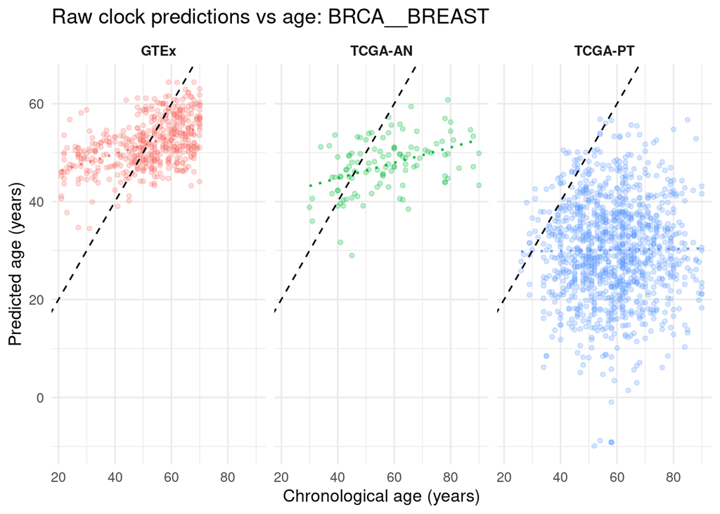

```r
plot_df <- bind_rows(
  tibble(sample_id = names(pred_gtex), cohort = "GTEx",    age_years = y_gtex[names(pred_gtex)],    pred_age = pred_gtex),
  tibble(sample_id = names(pred_pt),   cohort = "TCGA-PT", age_years = age_pt[names(pred_pt)],      pred_age = pred_pt),
  tibble(sample_id = names(pred_nt),   cohort = "TCGA-AN", age_years = age_nt[names(pred_nt)],      pred_age = pred_nt)
) %>%
  filter(!is.na(age_years), !is.na(pred_age))

ggplot(plot_df, aes(x = age_years, y = pred_age, colour = cohort)) +
  geom_point(alpha = 0.25, size = 1.2) +
  geom_smooth(method = "lm", se = FALSE, linetype = "dotted", linewidth = 0.8) +
  geom_abline(slope = 1, intercept = 0, linetype = "dashed") +
  facet_wrap(~ cohort, nrow = 1) +
  theme_minimal(base_size = 12) +
  theme(legend.position = "none",
        strip.text = element_text(face = "bold")) +
  labs(
    title = paste0("Raw clock predictions vs age: ", analysis_id),
    x = "Chronological age (years)",
    y = "Predicted age (years)"
  )
```

## Δ-age (Predicted − chronological)

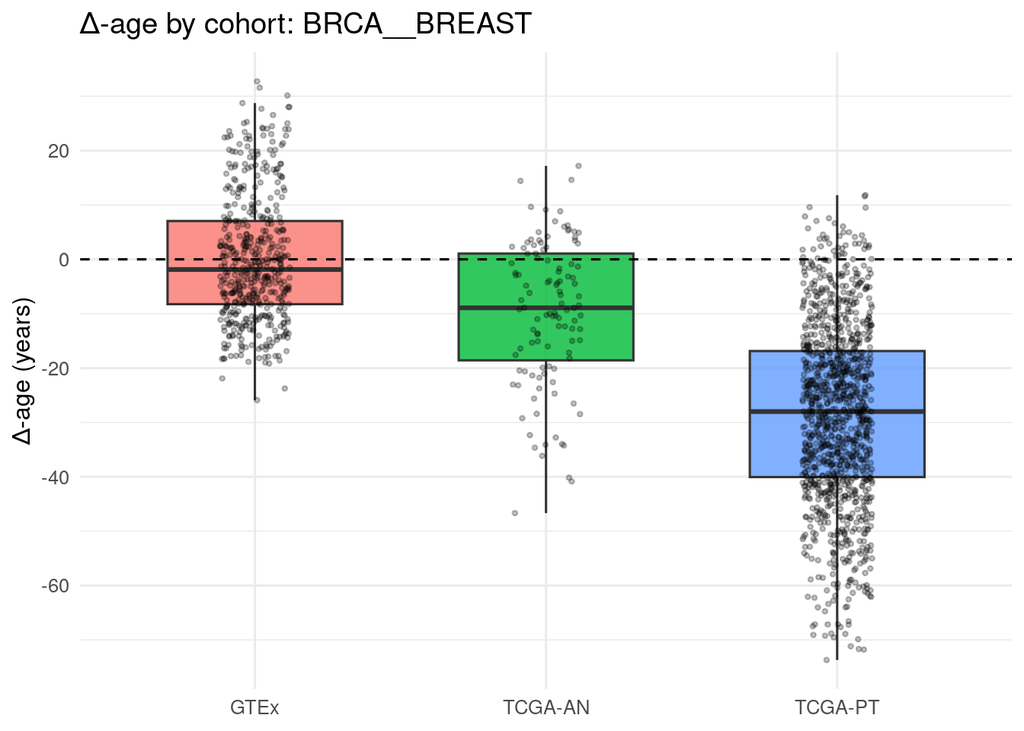

```r
delta_df <- plot_df %>%
  mutate(delta_age = pred_age - age_years)

ggplot(delta_df, aes(x = cohort, y = delta_age, fill = cohort)) +
  geom_boxplot(width = 0.6, outlier.shape = NA, alpha = 0.8) +
  geom_jitter(width = 0.12, alpha = 0.25, size = 0.8) +
  geom_hline(yintercept = 0, linetype = "dashed") +
  theme_minimal(base_size = 12) +
  theme(legend.position = "none") +
  labs(
    title = paste0("Δ-age by cohort: ", analysis_id),
    x = NULL,
    y = "Δ-age (years)"
  )
```

```r
delta_summary <- delta_df %>%
  group_by(cohort) %>%
  summarise(
    n = n(),
    mean = mean(delta_age),
    sd   = sd(delta_age),
    median = median(delta_age),
    IQR = IQR(delta_age),
    .groups = "drop"
  )

reactable_pretty(delta_summary)
```

| cohort | n | mean | sd | median | IQR |
| --- | --- | --- | --- | --- | --- |
| GTEx | 482 | -9.64e-14 | 11.6 | -1.87 | 15.3 |
| TCGA-AN | 112 | -9.78 | 13.3 | -8.92 | 19.6 |
| TCGA-PT | 1120 | -28.4 | 16.5 | -28 | 23.2 |

## Optional: evaluation capped to GTEx max age

```r
cap_df   <- NULL
cap_perf <- NULL
cap_plot <- NULL

if (isTRUE(params$do_age_capping)) {
  age_max <- suppressWarnings(max(y_gtex, na.rm = TRUE))

  if (!is.finite(age_max)) {
    vcat("Age-capped evaluation requested, but GTEx max age is not finite. Skipping.")
  } else {
    cap_df <- delta_df %>% filter(age_years <= age_max)

    vcat("Age-capped evaluation: max_age=", age_max,
         " | n(GTEx)=", sum(cap_df$cohort == "GTEx"),
         " | n(PT)=",   sum(cap_df$cohort == "TCGA-PT"),
         " | n(NAT)=",  sum(cap_df$cohort == "TCGA-AN"))

    if (nrow(cap_df) == 0) {
      vcat("Age-capped evaluation skipped: no samples ≤ max GTEx age after filtering.")
    } else {
      cap_perf <- cap_df %>%
        group_by(cohort) %>%
        summarise(
          n = n(),
          r = safe_cor(pred_age, age_years),
          MAE = mean(abs(pred_age - age_years)),
          RMSE = sqrt(mean((pred_age - age_years)^2)),
          .groups = "drop"
        )

      cap_plot <- ggplot(cap_df, aes(x = age_years, y = pred_age, colour = cohort)) +
        geom_point(alpha = 0.25, size = 1.2) +
        geom_smooth(method = "lm", se = FALSE, linetype = "dotted", linewidth = 0.8) +
        geom_abline(slope = 1, intercept = 0, linetype = "dashed") +
        facet_wrap(~ cohort, nrow = 1) +
        theme_minimal(base_size = 12) +
        theme(legend.position = "none",
              strip.text = element_text(face = "bold")) +
        labs(
          title = paste0("Predicted vs age (≤ GTEx max): ", analysis_id),
          x = "Chronological age (years)",
          y = "Predicted age (years)"
        )
    }
  }
}
```

```
## Age-capped evaluation: max_age= 70  | n(GTEx)= 482  | n(PT)= 902  | n(NAT)= 90
```

```r
if (isTRUE(params$do_age_capping) && !is.null(cap_perf) && nrow(cap_perf) > 0) {
  reactable_pretty(cap_perf)
}
```

| cohort | n | r | MAE | RMSE |
| --- | --- | --- | --- | --- |
| GTEx | 482 | 0.471 | 9.35 | 11.6 |
| TCGA-AN | 90 | 0.412 | 8.46 | 10.4 |
| TCGA-PT | 902 | 0.0051 | 24.3 | 27.9 |

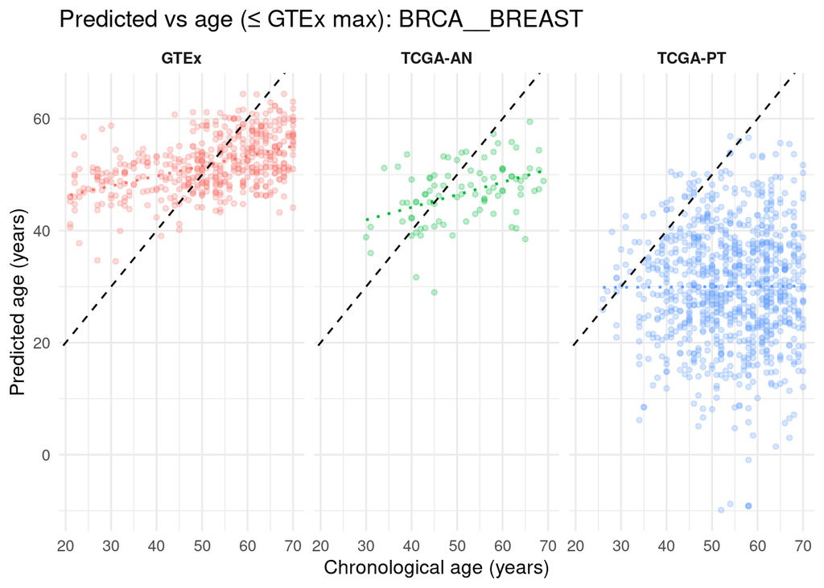

```r
if (isTRUE(params$do_age_capping) && !is.null(cap_plot)) {
  cap_plot
}
```

## Tumor-intra RAA (residual within tumors)

This is the **tumor-only** residual:

$$\mathrm{RAA}_{\mathrm{tum,intra}} = \hat y_{\mathrm{tum}} - (\alpha_T +
\beta_T \cdot \mathrm{Age})$$

It is useful for **tumor-only** downstream comparisons (stage, survival).

```r
raa_tum_intra <- NA_real_
if (length(pred_pt) && sum(is.finite(age_pt[names(pred_pt)])) >= 3) {
  age_pt_aligned <- age_pt[names(pred_pt)]

  ok <- complete.cases(pred_pt, age_pt_aligned)
  fit <- lm(pred_pt[ok] ~ age_pt_aligned[ok])

  alpha_T <- coef(fit)[1]
  beta_T  <- coef(fit)[2]

  raa_vals <- pred_pt[ok] - (alpha_T + beta_T * age_pt_aligned[ok])
  raa_tum_intra <- setNames(as.numeric(raa_vals), names(pred_pt)[ok])

  vcat("Tumor-intra bias line: alpha=", round(alpha_T, 3), " beta=", round(beta_T, 3),
      " | cor(RAA,Age)=", round(safe_cor(raa_vals, age_pt_aligned[ok]), 3))
} else {
  warning("Not enough tumors with age to compute tumor-intra RAA.")
}
```

```
## Tumor-intra bias line: alpha= 29.535  beta= 0.01  | cor(RAA,Age)= 0
```

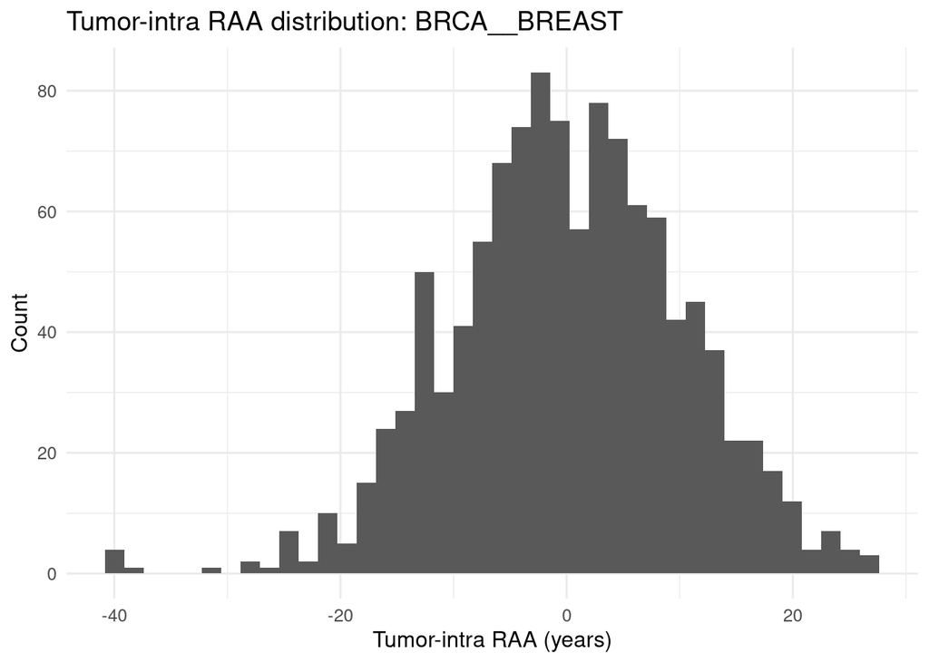

```r
if (!all(is.na(raa_tum_intra))) {
  raa_df <- tibble(sample_id = names(raa_tum_intra), RAA = as.numeric(raa_tum_intra))
  ggplot(raa_df, aes(x = RAA)) +
    geom_histogram(bins = 40) +
    theme_minimal(base_size = 12) +
    labs(title = paste0("Tumor-intra RAA distribution: ", analysis_id),
         x = "Tumor-intra RAA (years)", y = "Count")
}
```

## Save outputs for downstream analyses

```r
clock_results <- list(
  params = list(
    tcga_project = params$tcga_project,
    gtex_project = params$gtex_project,
    feature_set  = params$feature_set
  ),
  analysis_id = analysis_id,
  proc_dir    = proc_dir,

  # feature processing
  feature_names = colnames(x_gtex),
  x_center = x_center,
  x_scale  = x_scale,

  # tuning + training
  tuning = list(
    alpha_grid = alpha_grid,
    lambda_grid = lambda_grid,
    tune_table = tune_tbl,
    best_alpha = best_alpha,
    best_lambda = best_lambda,
    lambda_choice = params$lambda_choice
  ),
  cvfit_best = best_cvfit,
  enet_model = enet_model,

  # retained features (explicitly saved for convenience)
  retained = retained_tbl,

  # clock parameterizations (explicit contract)
  clock_raw = list(
    alpha = a_orig,
    beta  = b_orig
  ),
  clock_cs = list(
    # ClockSHAP standardized form:
    # yhat = alpha + sum_j beta_j * (x_j - mu_j) / sigma_j
    alpha = alpha_cs,
    beta  = beta_cs,
    mu    = mu,
    sigma = sigma
  ),

  # predictions (named by sample_id)
  pred = list(
    GTEx = pred_gtex,
    NAT  = pred_nt,
    Tumour = pred_pt
  ),

  # ages (named by sample_id where available)
  age = list(
    GTEx = y_gtex,
    NAT  = if (nrow(x_nt) > 0) age_nt else numeric(),
    Tumour = if (nrow(x_pt) > 0) age_pt else numeric()
  ),

  # delta-age + RAA objects
  raa = list(
    # Raw delta-age (pred - age) for tumors only (not bias-corrected)
    Tumour_delta_raw = if (length(pred_pt)) setNames(pred_pt - age_pt[names(pred_pt)], names(pred_pt)) else numeric(),

    # Tumor-only residuals (recommended for tumor-only downstream comparisons)
    Tumour_intra = raa_tum_intra
  ),

  # quick performance tables (optional)
  perf = list(
    raw = tab
  )
)

saveRDS(clock_results, file = file.path(proc_dir, paste0("clock_and_RAA_objects", suffix, ".rds")))

vcat("Saved clock_results to: ", file.path(proc_dir, paste0("clock_and_RAA_objects", suffix, ".rds")))
```

```
## Saved clock_results to:  /restricted/projectnb/agedisease/projects/pancancer_aging_pbock/manuscript_analyses/results/derived/GTEx/BRCA__BREAST/clock_and_RAA_objects-PC.rds
```